# 04-BFALgtseq-test4

1 February 2023

One primer pool.

## Taking a look at output from GTscore

```r
library(tidyverse)
```

The plot we want is the R1 reads where the FWD primer was found vs. the flashed read where the FWD primer was found.

```r
# read in the GTscore output

flashed <- read_tsv("../data/test4/flashed_locusSummary.txt") %>%
  select(Locus, `Primer Reads`) %>%
  rename(flashed_reads = `Primer Reads`)
R1 <- read_tsv("../data/test4/R1_locusSummary.txt") %>%
  select(Locus, `Primer Reads`) %>%
  rename(R1_reads = `Primer Reads`)
```

Look at those two df combined based on locus

```r
combo_df <- R1 %>%
  left_join(., flashed, by = "Locus")

combo_df %>%
  summarise(sum(R1_reads))
```

| sum(R1_reads) |
| --- |
| 2634753 |

```r
combo_df %>%
  summarise(sum(flashed_reads))
```

| sum(flashed_reads) |
| --- |
| 2282128 |

```r
# how many had 0 reads
combo_df %>%
  filter(R1_reads == 0)
```

| Locus | R1_reads | flashed_reads |
| --- | --- | --- |
| BFAL_scaffold_0_4330405 | 0 | 0 |
| BFAL_scaffold_5_523288 | 0 | 0 |
| BFAL_scaffold_10_1427435 | 0 | 0 |
| BFAL_scaffold_10_2628257 | 0 | 0 |
| BFAL_scaffold_10_3765633 | 0 | 0 |
| BFAL_scaffold_10_3913065 | 0 | 0 |
| BFAL_scaffold_14_2620367 | 0 | 0 |
| BFAL_scaffold_15_1957403 | 0 | 0 |
| BFAL_scaffold_19_1937583 | 0 | 0 |
| BFAL_scaffold_21_3344501 | 0 | 0 |

[output cut: 45 more lines]

```r
NA
```

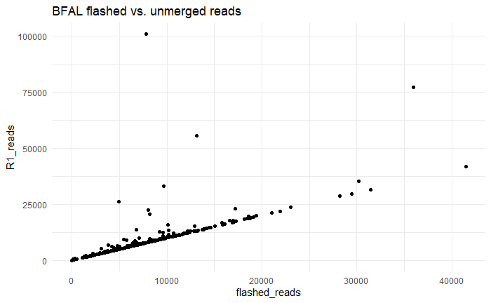

```r
combo_df %>%
  ggplot(aes(x = flashed_reads, y = R1_reads)) +
  geom_point() +
  labs(title = "BFAL flashed vs. unmerged reads") +
  theme_minimal()
```

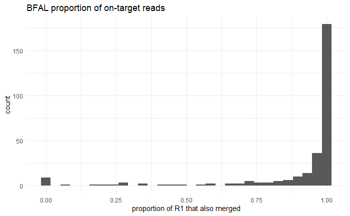

```r
# create a proportion difference
combo_df %>%
  mutate(prop = flashed_reads/R1_reads) %>%
  ggplot(aes(x = prop)) +
  geom_histogram() +
  labs(x = "proportion of R1 that also merged",
       title = "BFAL proportion of on-target reads") +
  theme_minimal()
```

```r
NA
NA
```

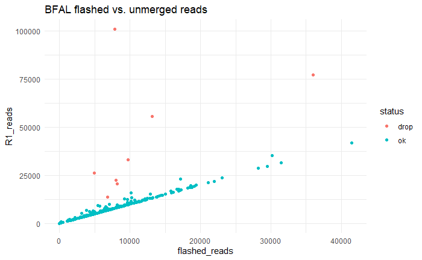

```r
combo_df %>%
  filter(!R1_reads == 0) %>% # these correspond to the 18 loci that I removed based on the first iteration.
  mutate(prop = flashed_reads/R1_reads) %>%
  #filter(prop < 0.75 & R1_reads > 10000) %>% # how many loci with < 75% on-target?
  mutate(status = ifelse(prop < 0.5 & R1_reads >5000, "drop", "ok")) %>%
  ggplot(aes(x = flashed_reads, y = R1_reads, color = status)) +
  geom_point() +
  labs(title = "BFAL flashed vs. unmerged reads") +
  theme_minimal()
```

Take a closer look at the loci that are still off-target. Otherwise, this looks pretty decent.

```r
droppers <- combo_df %>%
  filter(!R1_reads == 0) %>% # these correspond to the 18 loci that I removed based on the first iteration.
  mutate(prop = flashed_reads/R1_reads) %>%
  #filter(prop < 0.75 & R1_reads > 10000) %>% # how many loci with < 75% on-target?
  mutate(status = ifelse(prop < 0.5 & R1_reads >5000, "drop", "ok")) %>%
  filter(status == "drop") %>%
  arrange(desc(R1_reads))

droppers$Locus <- gsub("BFAL_", "", droppers$Locus)
```

So for those 8, where did they fall previously?

```r
prior <- read_csv("csv_outputs/BFALgtseq_test4_primer_conc_for_cherrypick.csv")
```

```r
prior %>%
  left_join(., droppers) %>%
  arrange(R1_reads)
```

| Plate Name | Well Position | Locus | new_ul | R1_reads | flashed_reads | prop | status |
| --- | --- | --- | --- | --- | --- | --- | --- |
| BFALgtseqPlate3R | E07 | scaffold_361_493591 | 3.33 | 13687 | 6805 | 0.49718711 | drop |
| BFALgtseqPlate4R | F03 | scaffold_770_254132 | 0.83 | 20468 | 8173 | 0.39930623 | drop |
| BFALgtseqPlate4R | E05 | scaffold_955_38248 | 1.25 | 22329 | 8014 | 0.35890546 | drop |
| BFALgtseqPlate1R | F05 | scaffold_16_3538528 | 2.50 | 26265 | 4940 | 0.18808300 | drop |
| BFALgtseqPlate4R | C07 | scaffold_1279_101665 | 2.50 | 33163 | 9694 | 0.29231372 | drop |
| BFALgtseqPlate3R | D05 | scaffold_314_405094 | 1.25 | 55700 | 13129 | 0.23570916 | drop |
| BFALgtseqPlate3R | H06 | scaffold_350_545162 | 0.83 | 77252 | 35962 | 0.46551546 | drop |
| BFALgtseqPlate3R | A11 | scaffold_519_500856 | 1.25 | 100924 | 7816 | 0.07744441 | drop |
| BFALgtseqPlate3R | E04 | scaffold_289_1045900 | 5.00 | NA | NA | NA | NA |
| BFALgtseqPlate1R | A08 | scaffold_30_2857044 | 5.00 | NA | NA | NA | NA |

[output cut: 270 more lines]

Interesting. So I increased the primer conc. on some of those loci and decreased it on others. Either way, I think I kick them out and then try genotyping multiple plates.

Maybe reduce the primer concentration on any loci with > 25,000 flashed reads:

```r
overampers <- combo_df %>%
  filter(flashed_reads > 25000)

overampers$Locus <- gsub("BFAL_", "", overampers$Locus)

# reduce the concentration of overamplifying loci
new_overamper_conc <- overampers %>%
  anti_join(., droppers) %>%
  left_join(., prior) %>%
  mutate(new_ul = ifelse(new_ul == 0.83, 0.5, 1))
```

```r
# beginning with the prior concentrations
# remove the loci to drop from round 4
# add the reduced primer concentration for the overampers
# remove the locus that has >2 alleles in many individuals (based on below)
tent_test5 <- prior %>%
  anti_join(., droppers) %>%
  anti_join(., overampers) %>%
  bind_rows(new_overamper_conc) %>%
  select(-R1_reads, -flashed_reads) %>%
  arrange(`Plate Name`, `Well Position`) %>%
  filter(Locus != "scaffold_519_157242")
```

```r
combo_df %>%
  filter(Locus %in% c("scaffold_608_211809", "scaffold_700_166185", "scaffold_37_1483238", "scaffold_48_3128896", "scaffold_453_725072", "scaffold_298_460712", "scaffold_1273_1937", "scaffold_336_592609"))
```

| Locus | R1_reads | flashed_reads |
| --- | --- | --- |

```r
NA
```

Keep these, but add anything < 1 ul by hand: if >5k reads

Final question: do I want to bump up the concentration of any of the low loci?

```r
# which loci are really struggling
# and either could use additional volume
# or should be dropped
combo_df %>%
  anti_join(., overampers) %>%
  anti_join(., droppers) %>%
  filter(R1_reads < 2000, flashed_reads > 0) %>%
  left_join(., prior)
```

| Locus | R1_reads | flashed_reads | Plate Name | Well Position | new_ul |
| --- | --- | --- | --- | --- | --- |
| BFAL_scaffold_3_875260 | 1978 | 1973 | NA | NA | NA |
| BFAL_scaffold_4_4005861 | 1684 | 1682 | NA | NA | NA |
| BFAL_scaffold_20_1133858 | 1533 | 1343 | NA | NA | NA |
| BFAL_scaffold_20_1698864 | 1099 | 1098 | NA | NA | NA |
| BFAL_scaffold_21_3344146 | 1670 | 1637 | NA | NA | NA |
| BFAL_scaffold_30_2857044 | 910 | 264 | NA | NA | NA |
| BFAL_scaffold_48_3128896 | 1446 | 1445 | NA | NA | NA |
| BFAL_scaffold_75_1184494 | 481 | 477 | NA | NA | NA |
| BFAL_scaffold_91_1220718 | 1826 | 1816 | NA | NA | NA |
| BFAL_scaffold_107_655108 | 1980 | 1968 | NA | NA | NA |

[output cut: 16 more lines]

```r
NA
NA
```

Take a look at some of the true losers here: < 1000 reads and volume bumped up to 5 ul!

```r
combo_df %>%
  anti_join(., overampers) %>%
  anti_join(., droppers) %>%
  filter(R1_reads < 1000, flashed_reads > 0) %>%
  left_join(., prior)
```

| Locus | R1_reads | flashed_reads | Plate Name | Well Position | new_ul |
| --- | --- | --- | --- | --- | --- |
| BFAL_scaffold_30_2857044 | 910 | 264 | NA | NA | NA |
| BFAL_scaffold_75_1184494 | 481 | 477 | NA | NA | NA |
| BFAL_scaffold_273_874676 | 452 | 429 | NA | NA | NA |
| BFAL_scaffold_289_1045900 | 412 | 108 | NA | NA | NA |
| BFAL_scaffold_646_455236 | 3 | 1 | NA | NA | NA |
| BFAL_scaffold_925_195188 | 440 | 395 | NA | NA | NA |
| BFAL_scaffold_1180_121024 | 550 | 117 | NA | NA | NA |
| BFAL_scaffold_1226_115783 | 249 | 246 | NA | NA | NA |

```r
test5_primer_pool <- tent_test5 %>%
  mutate(new_ul = ifelse(Locus %in% c("scaffold_75_1184494", "scaffold_925_195188", "scaffold_1226_115783"), 1, new_ul)) %>%
  mutate(new_ul = ifelse(Locus == "scaffold_273_874676", 4, new_ul))
```

Take a quick look at the distribution of reads for different volumes of primer sets.

```r
combo_df$Locus <- gsub("BFAL_", "", combo_df$Locus)
```

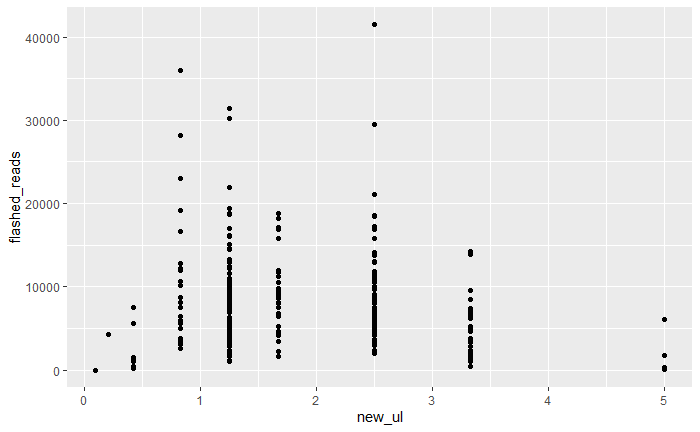

```r
combo_df %>%
  left_join(prior) %>%
  #filter(flashed_reads < 5000) %>%
  ggplot(aes(x = new_ul, y = flashed_reads)) +
  geom_point()
```

## Looking at genotypes from the .rds file

1. Do I have the read depth per locus to genotype these samples
2. Are there any loci that are mis-behaving? (>2 haplotypes per individual after filtering for read depth)

Take a look at the file produced by microhaplot from Sedna.

```r
test4 <- read_rds("../microhaplot/BFALgtseq_test4.rds")
```

```r
genos <- test4 %>%
  select(group, id, locus, haplo, depth, allele.balance, rank)


genos$locus <- gsub("_PCR_Product", "", genos$locus)
```

How many individuals in this file?

```r
genos %>%
  group_by(id) %>%
  tally()
```

| id | n |
| --- | --- |
| s100 | 332 |
| s101 | 339 |
| s102 | 348 |
| s103 | 366 |
| s104 | 274 |
| s105 | 213 |
| s106 | 313 |
| s107 | 261 |
| s108 | 272 |
| s109 | 264 |

[output cut: 83 more lines]

```r
NA
```

93 individuals out of 96 (including the blank, NTC)

```r
genos %>%
  group_by(locus) %>%
  tally()
```

| locus | n |
| --- | --- |
| scaffold_0_4543438 | 220 |
| scaffold_1078_116737 | 148 |
| scaffold_109_2235500 | 171 |
| scaffold_115_2200290 | 132 |
| scaffold_1164_119437 | 163 |
| scaffold_121_1829963 | 256 |
| scaffold_121_565678 | 155 |
| scaffold_123_1115977 | 136 |
| scaffold_127_1105814 | 189 |
| scaffold_1279_101665 | 167 |

[output cut: 133 more lines]

```r
NA
```

Key question:

how many alleles per individual (above what depth threshold)?

```r
genos %>%
  anti_join(., droppers, by = c("locus" = "Locus")) %>%
  filter(rank != 1 & allele.balance < 0.5) %>%
  group_by(locus) %>%
  tally()
```

| locus | n |
| --- | --- |
| scaffold_0_4543438 | 70 |
| scaffold_1078_116737 | 13 |
| scaffold_109_2235500 | 54 |
| scaffold_115_2200290 | 7 |
| scaffold_1164_119437 | 46 |
| scaffold_121_1829963 | 137 |
| scaffold_121_565678 | 17 |
| scaffold_123_1115977 | 8 |
| scaffold_127_1105814 | 49 |
| scaffold_1279_101843 | 24 |

[output cut: 126 more lines]

```r
NA
NA
```

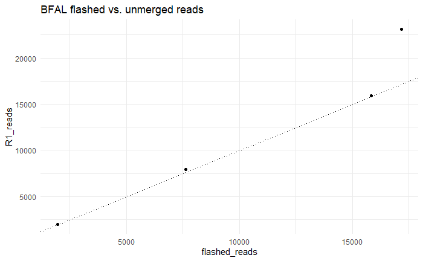

```r
multi_haps <- genos %>%
  anti_join(., droppers, by = c("locus" = "Locus")) %>%
  arrange(locus, id) %>%
  filter(depth > 10) %>%
  group_by(id, locus) %>%
  add_tally() %>%
  filter(n > 2) %>%
  ungroup() %>%
  select(locus) %>%
  unique() # how many loci?

multi_haps %>%
  left_join(., combo_df, by = c("locus" = "Locus")) %>%
   ggplot(aes(x = flashed_reads, y = R1_reads)) +
  geom_point() +
  geom_abline(linetype = "dotted") +
  labs(title = "BFAL flashed vs. unmerged reads") +
  theme_minimal()
```

```r
# clearly not off-target
```

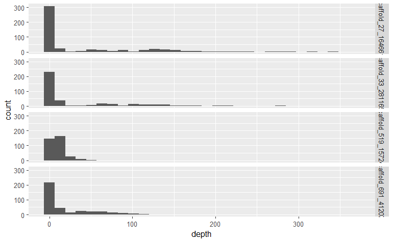

```r
multi_haps %>%
  left_join(., genos) %>%
  ggplot(aes(x = depth)) +
  geom_histogram() +
  facet_grid(rows = vars(locus))
```

```r
NA
```

```r
multi_haps %>%
  left_join(., genos) %>%
  group_by(locus, id) %>%
  filter(depth < 10) %>%
  tally() %>%
  filter(n > 2)
```

| locus | id | n |
| --- | --- | --- |
| scaffold_27_1646617 | s100 | 3 |
| scaffold_27_1646617 | s101 | 4 |
| scaffold_27_1646617 | s102 | 5 |
| scaffold_27_1646617 | s103 | 7 |
| scaffold_27_1646617 | s105 | 3 |
| scaffold_27_1646617 | s107 | 3 |
| scaffold_27_1646617 | s110 | 4 |
| scaffold_27_1646617 | s114 | 3 |
| scaffold_27_1646617 | s115 | 4 |
| scaffold_27_1646617 | s116 | 5 |

[output cut: 185 more lines]

Use a combination of read depth and allele balance filters to remove spurious alleles caused by sequencing error.

```r
# filter
genos_10reads <- genos %>%
  anti_join(., droppers, by = c("locus" = "Locus")) %>%
  arrange(locus, id) %>%
  filter(depth > 10,
         allele.balance > 0.4)

# check for loci with >2 alleles in any indiv
genos_10reads %>%
  group_by(locus, id) %>%
  tally() %>%
  filter(n > 2)
```

| locus | id | n |
| --- | --- | --- |
| scaffold_519_157242 | s117 | 3 |
| scaffold_519_157242 | s139 | 3 |
| scaffold_519_157242 | s140 | 3 |
| scaffold_519_157242 | s143 | 3 |
| scaffold_519_157242 | s188 | 3 |
| scaffold_519_157242 | s191 | 4 |
| scaffold_519_157242 | s192 | 3 |

```r
NA
```

All in the same locus. Let’s drop that one.

But take a look, first.

```r
genos_10reads %>%
  filter(locus == "scaffold_519_157242")
```

| group | id | locus | haplo | depth | allele.balance | rank |
| --- | --- | --- | --- | --- | --- | --- |
| BFAL | s100 | scaffold_519_157242 | TACAAC | 23 | 1.0000000 | 1 |
| BFAL | s100 | scaffold_519_157242 | NACAAC | 11 | 0.4782609 | 2 |
| BFAL | s101 | scaffold_519_157242 | TACAAC | 29 | 1.0000000 | 1 |
| BFAL | s101 | scaffold_519_157242 | NACAAC | 17 | 0.5862069 | 2 |
| BFAL | s102 | scaffold_519_157242 | TTTAAC | 26 | 1.0000000 | 1 |
| BFAL | s102 | scaffold_519_157242 | NTTAAC | 16 | 0.6153846 | 2 |
| BFAL | s103 | scaffold_519_157242 | TTTAAC | 26 | 1.0000000 | 1 |
| BFAL | s103 | scaffold_519_157242 | NTTAAC | 17 | 0.6538462 | 2 |
| BFAL | s104 | scaffold_519_157242 | TACAAC | 32 | 1.0000000 | 1 |
| BFAL | s106 | scaffold_519_157242 | TACAAC | 14 | 1.0000000 | 1 |

[output cut: 113 more lines]

Very sketchy.

Filter it out.

```r
genos_10reads %>%
  filter(locus != "scaffold_519_157242")
```

| group | id | locus | haplo | depth | allele.balance | rank |
| --- | --- | --- | --- | --- | --- | --- |
| BFAL | s100 | scaffold_0_4543438 | AGA | 200 | 1.0000000 | 1 |
| BFAL | s101 | scaffold_0_4543438 | GGA | 151 | 1.0000000 | 1 |
| BFAL | s102 | scaffold_0_4543438 | GGG | 103 | 1.0000000 | 1 |
| BFAL | s103 | scaffold_0_4543438 | GGA | 302 | 1.0000000 | 1 |
| BFAL | s104 | scaffold_0_4543438 | GAA | 67 | 1.0000000 | 1 |
| BFAL | s104 | scaffold_0_4543438 | GGA | 67 | 1.0000000 | 2 |
| BFAL | s105 | scaffold_0_4543438 | GAA | 36 | 1.0000000 | 1 |
| BFAL | s106 | scaffold_0_4543438 | GGA | 141 | 1.0000000 | 1 |
| BFAL | s106 | scaffold_0_4543438 | GGG | 122 | 0.8652482 | 2 |
| BFAL | s107 | scaffold_0_4543438 | GGA | 47 | 1.0000000 | 1 |

[output cut: 990 more lines]

```r
NA
```

Which ones are missing?

```r
no_genos <- prior %>%
  anti_join(., genos, by = c("Locus" = "locus"))
```

Hmm. Okay, that’s a lot of potential drop-out.

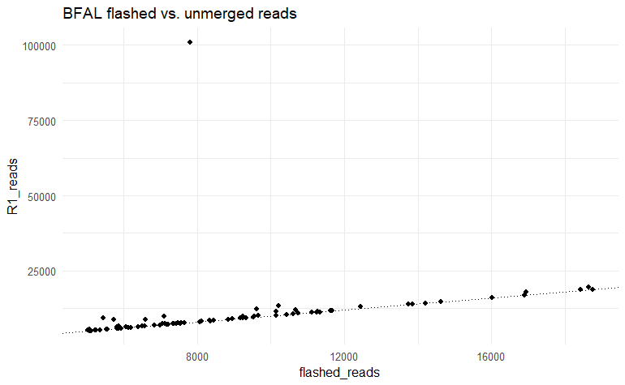

```r
combo_df %>%
  right_join(., no_genos) %>%
  filter(flashed_reads > 5000) %>%
  ggplot(aes(x = flashed_reads, y = R1_reads)) +
  geom_point() +
  geom_abline(linetype = "dotted") +
  labs(title = "BFAL flashed vs. unmerged reads") +
  theme_minimal()
```

```r
NA
```

```r
combo_df %>%
  right_join(., no_genos) %>%
  filter(new_ul > 2.5)
```

| Locus | R1_reads | flashed_reads | Plate Name | Well Position | new_ul |
| --- | --- | --- | --- | --- | --- |
| scaffold_7_15896 | 14298 | 14208 | BFALgtseqPlate1R | B02 | 3.33 |
| scaffold_20_1133858 | 1533 | 1343 | BFALgtseqPlate1R | A06 | 3.33 |
| scaffold_20_1698864 | 1099 | 1098 | BFALgtseqPlate1R | B06 | 3.33 |
| scaffold_20_959062 | 7458 | 7434 | BFALgtseqPlate1R | C06 | 3.33 |
| scaffold_21_3344146 | 1670 | 1637 | BFALgtseqPlate1R | D06 | 3.33 |
| scaffold_23_2891193 | 5045 | 4648 | BFALgtseqPlate1R | G06 | 3.33 |
| scaffold_25_236179 | 9857 | 7096 | BFALgtseqPlate1R | B07 | 3.33 |
| scaffold_30_2857044 | 910 | 264 | BFALgtseqPlate1R | A08 | 5.00 |
| scaffold_55_1337297 | 3605 | 3599 | BFALgtseqPlate1R | B11 | 3.33 |
| scaffold_57_3176048 | 12359 | 9616 | BFALgtseqPlate1R | H11 | 3.33 |

[output cut: 17 more lines]

Trying to figure out why some loci were not included in the rds files… could it be because those loci have no variation in the set of samples genotyped in this 96-plate?

```r
pos.info <- read_rds("../microhaplot/BFALgtseq_test4_posinfo.rds")

pos.info
```

| locus | pos |
| --- | --- |
| scaffold_0_4543438_PCR_Product | 38,40,63 |
| scaffold_1078_116737_PCR_Product | 78 |
| scaffold_109_2235500_PCR_Product | 78 |
| scaffold_115_2200290_PCR_Product | 58 |
| scaffold_1164_119437_PCR_Product | 32,51,54,68,96,115 |
| scaffold_121_1829963_PCR_Product | 2,42,54,93 |
| scaffold_121_565678_PCR_Product | 44 |
| scaffold_123_1115977_PCR_Product | 50 |
| scaffold_127_1105814_PCR_Product | 73,76,81 |
| scaffold_1279_101665_PCR_Product | 44,86 |

[output cut: 133 more lines]

Freebayes filtering step:

–haplotype-length 0 -kwVa -X -u -i -f

-X –throw-away-mnp-obs Remove MNP observations from input. -u –throw-away-complex-obs Remove complex allele observations from input. -i –throw-away-indels-obs Remove indel observations from input.

If that’s the case, just take a peak at a PCA for these filtered genotypes to evaluate whether there’s any obvious structure among these bycatch samples.

The format I need for the PCA is strata, indiv, markers, genotype (allele idx)

```r
# here is the starting dataframe
tmp_df <- genos_10reads %>%
  filter(locus != "scaffold_519_157242") %>%
  rename(indiv = id, allele = haplo, gene_copy = rank) %>%
  arrange(indiv, locus, gene_copy, allele) %>%
  select(-allele.balance, -depth)

expanded.df <- tmp_df %>%
  select(indiv) %>%
  unlist() %>%
  unname() %>%
  expand.grid(indiv = ., locus = unique(tmp_df$locus), gene_copy = 1:2, stringsAsFactors = FALSE) %>%
  as_tibble() %>%
  left_join(., tmp_df) %>%
  arrange(indiv, locus, gene_copy, allele) %>%
  unique() %>%
  mutate(group = "BFAL")
expanded.df %>%
  group_by(indiv, locus) %>%
  mutate(allele = ifelse(gene_copy == 2 & is.na(allele), "test", allele)) %>%
  filter(allele == "test")
```

| indiv | locus | gene_copy | group | allele |
| --- | --- | --- | --- | --- |
| s100 | scaffold_0_4543438 | 2 | BFAL | test |
| s100 | scaffold_1078_116737 | 2 | BFAL | test |
| s100 | scaffold_115_2200290 | 2 | BFAL | test |
| s100 | scaffold_121_1829963 | 2 | BFAL | test |
| s100 | scaffold_121_565678 | 2 | BFAL | test |
| s100 | scaffold_123_1115977 | 2 | BFAL | test |
| s100 | scaffold_1327_103421 | 2 | BFAL | test |
| s100 | scaffold_14_5075430 | 2 | BFAL | test |
| s100 | scaffold_143_1756997 | 2 | BFAL | test |
| s100 | scaffold_146_16700 | 2 | BFAL | test |

[output cut: 990 more lines]

```r
#   mutate(across(c(indiv, locus),
#                 ~ifelse(gene_copy == 2 & is.na(allele),
#                         .[gene_copy == 1 & !is.na(allele)], .)))
```

```r
in_need_of_gene1 <- expanded.df %>%
  filter(gene_copy == 2 & is.na(allele)) %>%
  select(-allele)

hets <- expanded.df %>%
  filter(gene_copy == 2 & !is.na(allele)) %>%
  select(indiv, locus)
  # left_join(., expanded.df, by = c("indiv", "locus")) %>%
  # filter(gene_copy.x != gene_copy.y)

full_het_df <- hets %>%
  left_join(., expanded.df)
# create a dataframe with the alleles to join to the gene_copy 2
homozygotes_to_join <- expanded.df %>%
  anti_join(., hets) %>%
  filter(gene_copy == 1) %>%
  select(indiv, locus, allele)
hom_genecopy1 <- homozygotes_to_join %>%
  select(-allele) %>%
  left_join(., expanded.df) %>%
  filter(gene_copy != 2)
# join the alleles to the homozygotes
hom_genecopy2 <- in_need_of_gene1 %>%
  left_join(homozygotes_to_join)
# put all pieces back together:
complete_df <- hom_genecopy2 %>%
  bind_rows(., full_het_df, hom_genecopy1) %>%
  arrange(indiv, locus, gene_copy)
```

```r
# look at the missing data per locus
complete_df %>%
  filter(is.na(allele)) %>%
  group_by(locus) %>%
  tally() %>%
  arrange(desc(n))
```

| locus | n |
| --- | --- |
| scaffold_81_820039 | 184 |
| scaffold_700_166185 | 180 |
| scaffold_91_1220718 | 88 |
| scaffold_143_1756997 | 68 |
| scaffold_109_2235500 | 64 |
| scaffold_487_133339 | 60 |
| scaffold_1589_18141 | 54 |
| scaffold_184_734991 | 54 |
| scaffold_4_4005861 | 52 |
| scaffold_148_727111 | 40 |

[output cut: 113 more lines]

```r
# remove any locus with >50% missing data
# for 96 inds
loci_keepers <- complete_df %>%
  filter(is.na(allele)) %>%
  group_by(locus) %>%
  tally() %>%
  filter(n < 96) %>% # how many missing alleles?
  select(-n)
```

```r
# just the loci with enough data across all samples
genos_ordered_df <- loci_keepers %>%
  left_join(., complete_df)
```

```r
# first make integers of the alleles
alle_idxs <- genos_ordered_df %>%
  dplyr::select(indiv, locus, gene_copy, allele) %>%
  group_by(locus) %>%
  mutate(alleidx = as.integer(factor(allele, levels = unique(allele)))) %>%
  ungroup() %>%
  arrange(indiv, locus, alleidx) # rubias can handle NA's, so no need to change them to 0's
```

Make the df match the requirements for tidy_genomic_data

```r
long_df <- alle_idxs %>%
  select(-allele, -gene_copy) %>%
  mutate(group = "BFAL") %>%
  #left_join(., spp_indiv) %>%
  #select(species, everything()) %>%
  rename(INDIVIDUALS = indiv, STRATA = group, MARKERS = locus, GT = alleidx)
```

Genotypes should be coded with 3 integers for each alleles. 6 integers in total for the genotypes. e.g. 001002 or 111333 (for heterozygote individual). 6 integers WITH separator: e.g. 001/002 or 111/333 (for heterozygote individual). The separator can be any of these: “/”, “:”, “_“,”-“,”.”, and will be removed.

```r
#library("DescTools")

# create 3 digit integers from the genotypes
long_df$GT3 <- Format(long_df$GT, ldigits = 3, digits = 0)

head(long_df)
```

| INDIVIDUALS | MARKERS | GT | STRATA | GT3 |
| --- | --- | --- | --- | --- |
| s100 | scaffold_0_4543438 | 1 | BFAL | 001 |
| s100 | scaffold_0_4543438 | 1 | BFAL | 001 |
| s100 | scaffold_1078_116737 | 1 | BFAL | 001 |
| s100 | scaffold_1078_116737 | 1 | BFAL | 001 |
| s100 | scaffold_109_2235500 | 1 | BFAL | 001 |
| s100 | scaffold_109_2235500 | 2 | BFAL | 002 |

```r
# NAs hold
# long_df %>%
#   filter(is.na(GT3))

# fix NAs
long_df0s <- long_df %>%
  mutate(GT3 = ifelse(is.na(GT3), "000", GT3))
```

Now combine the GT3 column per indiv/marker:

```r
# make the genos characters and then try pasting them as strings
long_df0s$GT3 <- as.character(long_df0s$GT3)

long_df3digit <- long_df0s %>%
  group_by(INDIVIDUALS, MARKERS) %>%
  arrange(GT3, .by_group = TRUE) %>%
  summarise(GENOTYPE = toString(GT3))
# paste strings together
long_df3digit$GENOTYPE <- gsub(", ","",long_df3digit$GENOTYPE)


# add back on species identity as strata
df_for_conversion <- long_df0s %>%
  select(-GT, -GT3) %>%
  left_join(., long_df3digit) %>%
  unique() %>%
  rename(GT = GENOTYPE) %>%
  mutate(GT = ifelse(GT == "000000", NA, GT))
df_for_conversion$STRATA <- as.factor(df_for_conversion$STRATA)

# check on NAs here
df_for_conversion %>%
  filter(str_detect(INDIVIDUALS, "s"))
```

| INDIVIDUALS | MARKERS | STRATA | GT |
| --- | --- | --- | --- |
| s100 | scaffold_0_4543438 | BFAL | 001001 |
| s100 | scaffold_1078_116737 | BFAL | 001001 |
| s100 | scaffold_109_2235500 | BFAL | 001002 |
| s100 | scaffold_115_2200290 | BFAL | 001001 |
| s100 | scaffold_1164_119437 | BFAL | 001002 |
| s100 | scaffold_121_1829963 | BFAL | 001001 |
| s100 | scaffold_123_1115977 | BFAL | 001001 |
| s100 | scaffold_127_1105814 | BFAL | 001002 |
| s100 | scaffold_1279_101843 | BFAL | 001002 |
| s100 | scaffold_1327_103421 | BFAL | 001001 |

[output cut: 990 more lines]

```r
library(radiator)
# use the radiator package for this conversion
genind_df <- write_genind(df_for_conversion)
```

Now that the data is a genind object, go ahead and run the PCA.

Make PCA

```r
library(adegenet)
# Allele presence absence data are extracted and NAs replaced using tab:
datasetX <- tab(genind_df, NA.method="mean") # double check that is this the appropriate method.

# make PCA
dataset_pca1 <- dudi.pca(datasetX, center = TRUE, scannf = FALSE, scale=FALSE, nf = 1000)

# colors
mycol <- colorRampPalette(c("darkgreen", "deepskyblue", "aquamarine4", "seagreen4", "cadetblue", "cyan", "darkblue", "midnightblue", "blue", "dodgerblue", "darkcyan", "darkslateblue", "slateblue", "steelblue4", "skyblue", "paleturquoise4", "brown", "royalblue", "purple4", "orange", "darkorange", "darkgoldenrod", "chocolate", "tan4", "saddlebrown", "sienna", "navajowhite4", "darkgray", "black", "pink"))(55)

# plot with factor labels
pdf("pdf_outputs/BFALgtseq_test4_pca.pdf", width = 10, height = 10)
s.class(dataset_pca1$li, fac=pop(genind_df), wt = rep(1, length(pop(genind_df))), clabel = .8, grid = FALSE, cellipse = 2,
        xax=1, yax=2, col=transp(mycol,.8),
        axesel=FALSE, cstar=0, cpoint=1)
dev.off()
```

It would be nice to know if 121 loci are sufficient, because then I could put more plates on a given sequencing run with fewer loci.

Seems like the thing to do would be to run the plate and a half of reference samples with all loci and those that don’t have useful variation could be dropped.

Output the concentrations for test5/genotyping baseline:

```r
primerpool <- test5_primer_pool %>% # do a little formatting
  mutate(`Destination Plate` = "BFALgtseq_test5",
         `Destination Well` = "NA")

primerpool$`Plate Name` <- gsub("R", "", primerpool$`Plate Name`)

primerpool %>%
  write_csv("csv_outputs/BFALgtseq_test5_primer_cherrypick.csv")
```